# **Exploring the Legacy of Redlining on Environmental Justice in Los Angeles**

Yifei Liu

2023-10-17

## Background

Present-day environmental justice may reflect legacies of injustice in the past. The United States has a long history of racial segregation which is still visible. During the 1930’s the Home Owners’ Loan Corporation (HOLC), as part of the New Deal, rated neighborhoods based on their perceived safety for real estate investment. Their ranking system, (A (green), B (blue), C (yellow), D (red)) was then used to block access to loans for home ownership. Colloquially known as “redlining”, this practice has had widely-documented consequences not only for community wealth, but also health.[^1] Redlined neighborhoods have less greenery[^2] and are hotter than other neighborhoods.[^3]

A recent study found that redlining has not only affected the environments communities are exposed to, it has also shaped our observations of biodiversity.[^4] Community or citizen science, whereby individuals share observations of species, is generating an enormous volume of data. Ellis-Soto and co-authors found that redlined neighborhoods remain the most undersampled areas across 195 US cities. This gap is highly concerning, because conservation decisions are made based on these data.

For further reading on the subject, regfer to the coverage by the [New York Times](https://www.nytimes.com/interactive/2020/08/24/climate/racism-redlining-cities-global-warming.html) and EOS.

## Project Description

This project explores the impacts of historical redlining on current environmental justice issues in Los Angeles. It investigates how redlining — a discriminatory practice from the 1930s that graded neighborhoods for loan eligibility based on racial composition and other factors — has shaped current environmental disparities. This analysis brings together historical HOLC grade designations, environmental data from EJScreen, and biodiversity observations from the Global Biodiversity Information Facility.

## Project Goals

The primary objectives of this project are to:

- Analyze the relationship between historical redlining grades and current environmental indicators.
- Investigate biodiversity disparities in areas affected by redlining.
- Utilize spatial analysis and data visualization to present findings effectively.

## Skills Demonstrated

- **Spatial Data Handling**: Proficiency in managing and analyzing spatial data with `sf` and `tmap` in R.
- **Data Wrangling and Analysis**: Utilizing `tidyverse` tools for data cleaning and analysis.
- **Statistical Analysis**: Ability to derive meaning insights from statistical summaries and comparisons.
- **Effective Visualization**: Creating informative and interpretive visualizations with `tmap` and `ggplot2`.

## Data Sources and Preparation

### EJScreen

We will be working with data from the United States Environmental Protection Agency’s EJScreen: Environmental Justice Screening and Mapping Tool. According to the [US EPA website](https://www.epa.gov/ejscreen/purposes-and-uses-ejscreen), EJScreen provides on environmental and demographic information for the US at the Census tract and [block group](https://en.wikipedia.org/wiki/Census_block_group) levels. This data helps assess current environmental disparities in Los Angeles County.

We will be working with block group data that has been downloaded from the [EPA site](https://www.epa.gov/ejscreen/download-ejscreen-data). To understand the associated data columns, we will need to explore the Technical Documentation and column description spreadsheet available in the data folder and the [limitations and caveats](https://www.epa.gov/ejscreen/limitations-and-caveats-using-ejscreen) of the data.

### Mapping Inequality

A team of researchers, led by the [Digital Scholarship Lab](https://dsl.richmond.edu/) at the University of Richmond have digitized maps and information from the HOLC as part of the [Mapping Inequality](https://dsl.richmond.edu/panorama/redlining/#loc=5/39.1/-94.58) project.

We will be working with maps of HOLC grade designations for Los Angeles. Information on the data can be found [here](https://dsl.richmond.edu/panorama/redlining/#loc=5/39.1/-94.58&text=downloads).[^5] These will serve as a basis for understanding historical redlining practices in Los Angeles.

### Biodiversity observations

Data from the Global Biodiversity Information Facility on bird observations from 2021 onwards offers insights into current biodiversity patterns in Los Angeles. Global Biodiversity Information Facility is the largest aggregator of biodiversity observations in the world. Observations typically include a location and date that a species was observed.

## Analysis Workflow

### Data import and Prepararion

#### Load relevant packages

```r
library(sf)
library(tmap)
library(tidyverse)
library(knitr)
library(ggplot2)
```

#### Data Reading

```r
# read in EJScreen data and filter to LA
LA <- st_read("data/EJSCREEN_2023_BG_StatePct_with_AS_CNMI_GU_VI.gdb/",
              query = "SELECT * FROM EJSCREEN_StatePctiles_with_AS_CNMI_GU_VI\
              WHERE CNTY_NAME = 'Los Angeles County'",
              quiet = TRUE)

# import redlining data
LA_redlining <- st_read("https://dsl.richmond.edu/panorama/redlining/static/citiesData/CALosAngeles1939/geojson.json",
              quiet = TRUE) %>%
  st_make_valid()

# read in bird data
bird <- st_read("data/gbif-birds-LA", quiet = TRUE) %>%
  filter(year == 2022)
```

### Investigate the legacy of redlining in current environmental (in)justice

#### Waste Water Discharge Analysis

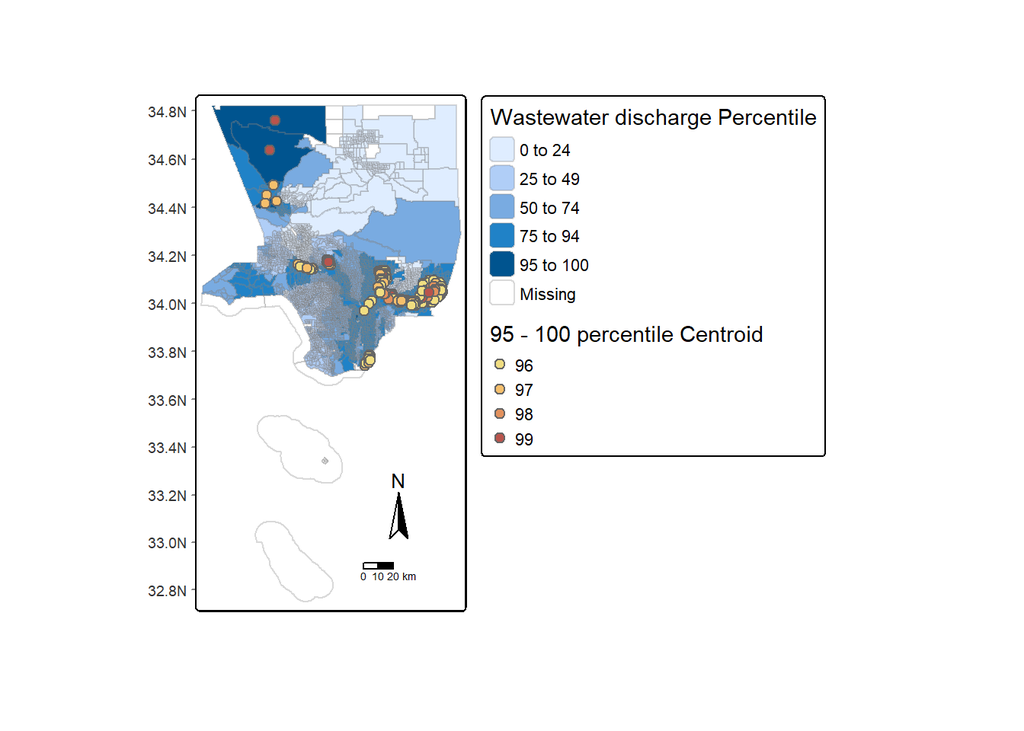

```r
# select wastewater data
wastewater <- LA %>%
  select(ID, P_PWDIS)

# filter to census block groups > 95th wastewater discharge
ab_wastewater <- wastewater %>%
  filter(P_PWDIS > 95)

# create centroids of wastewater
abww_centroid <- st_centroid(ab_wastewater)

# make map of wastewater discharge
breaks_fill = c(0, 25, 50, 75, 95, 100)
tm_shape(wastewater) +
  tm_fill("P_PWDIS",
          title = "Wastewater discharge Percentile",
          breaks = breaks_fill,
          colorNA = "White",
          border.col = "#8080804D",
          border.lwd = 0.1) +
  tm_shape(abww_centroid) +
  tm_symbols(col = "P_PWDIS",
             palette = "heat",
             size = 0.5,
             title.col = "95 - 100 percentile Centroid",
             legend.show = TRUE) +
  tm_compass(type = "arrow", position = c("right","bottom"), size = 2) +
  tm_scalebar(position = c("right","bottom")) +
  tm_graticules(lines = FALSE)
```

#### Socioeconomic and Environmental Impact Analysis

The objective of this section is to find low-income population percentage and environmental factors across census block groups.

First we will find the percent of low income census block groups. The census block groups that have less than 5% of the population is considered low income.

```r
# filter low income data
cb1 <- LA %>%
  filter(LOWINCPCT < 0.05) %>%
  nrow()/nrow(LA)*100

# print results
print(paste("Percent of census block groups:", cb1, "%"))
```

```
## [1] "Percent of census block groups: 6.11439842209073 %"
```

Secondly, we will find the percent of census block groups that are:  
- above the 80th percentile for Particulate Matter 2.5 AND  
- above the 80th percentile for Superfund proximity

```r
# filter data
cb2 <- LA %>%
  filter(P_D2_PM25 > 80) %>%
  filter(P_D2_PNPL > 80) %>%
  nrow()/nrow(LA)*100

# print results
print(paste("Percent of census block groups:", cb2, "%"))
```

```
## [1] "Percent of census block groups: 30.9816416325292 %"
```

#### Redlining Map Visualization

We will make a map of historical redlining boundaries, colored by HOLC grade.

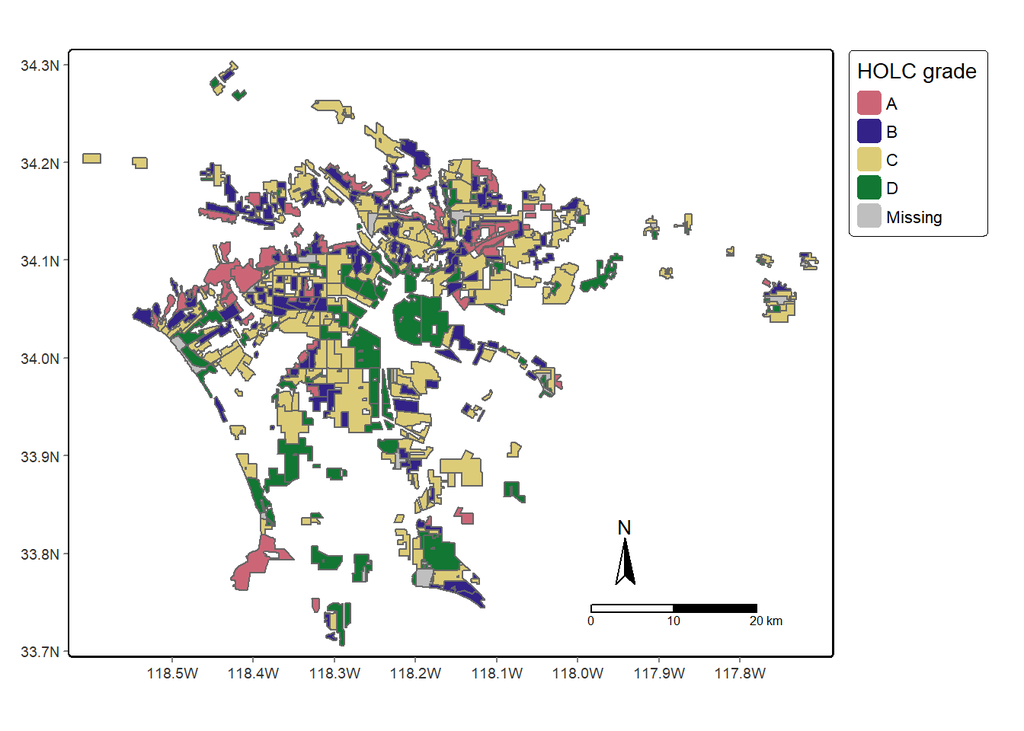

```r
# map redlining
tm_shape(LA_redlining) +
  tm_fill("grade", title = "HOLC grade") +
  tm_borders() +
  tm_compass(type = "arrow", position = c("right","bottom"), size = 2) +
  tm_scalebar(position = c("right","bottom")) +
  tm_graticules(lines = FALSE)
```

#### Finding the Number of Census Block Groups within HOLC Grades

We will analyze census block groups overlap with historical redlining areas.

```r
# Transform data to same CRS
LA <- st_transform(LA, crs = st_crs(LA_redlining))

# filter the CBG in redlining
LA_in_rd <- LA %>%
  st_filter(y = LA_redlining, .predicate = st_intersects)

# print results
print(paste("Number of census block groups that fall within areas with HOLC grades:",
          nrow(LA_in_rd)))
```

```
## [1] "Number of census block groups that fall within areas with HOLC grades: 3991"
```

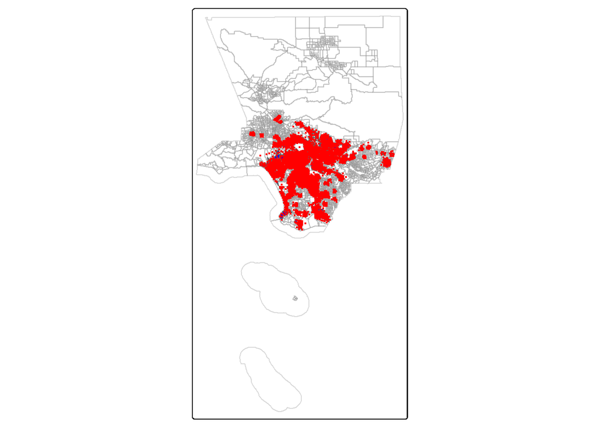

```r
# Check LA_in_rd by visualizing
tm_shape(LA) +
  tm_borders(col = "#8080804D") +
  tm_shape(LA_redlining) +
  tm_polygons(fill = "blue") +
  tm_shape(LA_in_rd) +
  tm_dots(fill = "red")
```

#### Summarizing Current Conditions within Redlining Categories

We will summarize current conditions based on EJScreen data within historical redlining categories using the mean of the following variables:  
-% low income.  
- percentile for particulate Matter 2.5.  
- percentile for low life expectancy.  
- percentile for air toxics cancer risk

```r
# spatial join
LA_in_rd_join <- st_join(LA_in_rd, LA_redlining, join = st_intersects, left = FALSE)

# summary table
summary <- st_drop_geometry(LA_in_rd_join) %>%
  filter(!is.na(grade)) %>%
  group_by(grade) %>%
  summarise(
    low_income = mean(LOWINCPCT, na.rm = TRUE),
    p_pm_25 = mean(P_PM25, na.rm = TRUE),
    p_low_life_exp = mean(P_LIFEEXPPCT, na.rm = TRUE),
    p_air_cancer = mean(P_CANCER, na.rm = TRUE)
  )

kable(summary)
```

| grade | low_income | p_pm_25 | p_low_life_exp | p_air_cancer |
| --- | --- | --- | --- | --- |
| A | 0.1497511 | 72.16036 | 23.75982 | 44.00670 |
| B | 0.2420120 | 76.33898 | 37.42025 | 47.68659 |
| C | 0.3408981 | 78.81884 | 47.88017 | 54.55468 |
| D | 0.3919059 | 80.23700 | 53.03621 | 56.57589 |

**The results from the summary table clearly reveals the environmental and socioeconomic disparities among the historical redlining categories. Census block groups with the highest redlining grade, “A”, exhibit the best conditions with the lowest percentages of low income (14.9%), lowest PM 2.5 percentiles (72.1%), lowest low life expectancy percentile (23.7%), and lowest air toxics cancer risk percentile (44.0%). On the contrary, census block groups with the lowest redlining grade, “D”, bears the worst conditions, demonstrating the highest percentages or percentiles across the variables (39.1%, 80.2%, 53.1%, 56.5%, respectively). This gradient is consistently observed across all categories, with areas labeled “B” and “C” facing intermediate challenges.**

### Investigate the legacy of redlining in biodiversity observations

#### Analyzing Biodiversity Observations in Redlined Areas

For bird observations from 2022 that fall within neighborhoods with HOLC grads, we will find the percent of observations within each redlining categories and plot results. We need to make sure that the bird observations have the same CRS as redlining data.

```r
# transform to same CRS as LA_redlining
bird <- st_transform(bird, crs = st_crs(LA_redlining))

# spatial join
bird_2022_in_rd <- st_join(bird, LA_redlining, join = st_intersects, left = FALSE)

# total number of birds in the table
num_bird_in_rd <- nrow(bird_2022_in_rd %>% filter(!is.na(grade)))

# summary table
summary_bird <- st_drop_geometry(bird_2022_in_rd) %>%
  filter(!is.na(grade)) %>%
  group_by(grade) %>%
  summarise(
    count = n(),
    percent = count/num_bird_in_rd
  )

# print summary table
kable(summary_bird)
```

| grade | count | percent |
| --- | --- | --- |
| A | 1073 | 0.1567568 |
| B | 1329 | 0.1941563 |
| C | 2439 | 0.3563185 |
| D | 2004 | 0.2927684 |

#### Visualizing Bird Observation Data

We will make a histogram for bird observation percents across HOLC grades in LA.

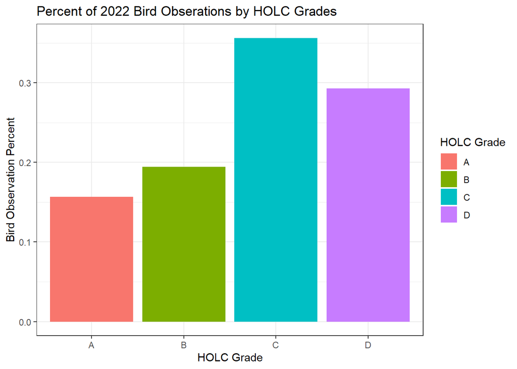

```r
# plot histogram
bird_plot <-ggplot(summary_bird,
                   aes(x = grade, y = percent, fill = grade)) +
  geom_bar(stat = "identity") +
  theme_bw() +
  labs(x = "HOLC Grade",
       y = "Bird Observation Percent",
       title = "Percent of 2022 Bird Obserations by HOLC Grades",
       fill = "HOLC Grade")

bird_plot
```

**The summary table and the bar plot illustrate the distribution of bird observations across the historical redlining categories in Los Angeles in 2022. Notably, “C” grade regions, not the expected “A” or “D” grades, lead with 35.7% of observations, while “A” grade regions have the fewest at 15.7%. It is surprising to see this pattern, as I expected more green spaces in higher-graded region, based on their superior environmental and socioeconomic scores in the previous summary table. This pattern suggest that bird abundance in LA is not strictly influenced by environmental and socioeconomic indicators computed in HOLC grades. Factors such as green spaces, habitat availability, and urbanization levels may contribute to these patterns, raising issue about the complex relationship between urbanization and biodiversity.**

[^1]: Gee, G. C. (2008). A multilevel analysis of the relationship between institutional and individual racial discrimination and health status. American journal of public health, 98(Supplement_1), S48-S56.
[^2]: Nardone, A., Rudolph, K. E., Morello-Frosch, R., & Casey, J. A. (2021). Redlines and greenspace: the relationship between historical redlining and 2010 greenspace across the United States. Environmental health perspectives, 129(1), 017006.
[^3]: Hoffman, J. S., Shandas, V., & Pendleton, N. (2020). The effects of historical housing policies on resident exposure to intra-urban heat: a study of 108 US urban areas. Climate, 8(1), 12.
[^4]: Ellis-Soto, D., Chapman, M., & Locke, D. H. (2023). Historical redlining is associated with increasing geographical disparities in bird biodiversity sampling in the United States. Nature Human Behaviour, 1-9.
[^5]: Robert K. Nelson, LaDale Winling, Richard Marciano, Nathan Connolly, et al., “Mapping Inequality,” American Panorama, ed. Robert K. Nelson and Edward L. Ayers, accessed October 17, 2023, https://dsl.richmond.edu/panorama/redlining/